# quiz3_review

```python
from datascience import *
import numpy as np

%matplotlib inline
import matplotlib.pyplot as plots
plots.style.use('fivethirtyeight')
```

## If, Elif, Else

Write a function that generates a random number between 1 and 6 (inclusive). If the random number is 1, return the string 'One'. If the random number is 2, return the string 'Two'. For all other random numbers, return the string 'Neither one nor two'.

```python
def random_example():
    random = make_array(1,2,3,4,5,6)
    random = np.random.choice(random)

    if random == 1:
        return 'One'

    elif random == 2:
        return 'Two'

    else:
        return 'Neither one nor two'


random_example()
```

```
'Two'
```

### Solution

```python
def random_example():
    six_arr = make_array(1,2,3,4,5,6)
    rand = np.random.choice(outcomes)

    if rand == 1:
        return 'One'
    elif rand == 2:
        return 'Two'
    else:
        return 'Neither one nor two'
```

## For loops and append

Suppose a bag contains 3 red balls and 7 green balls. Use a for loop and sample_proportions to perform the following experiment 1000 times:

- draw a ball from the bag 10 times
- calculate the number of red balls drawn
- append the number of red balls to an array

After the loop completes, visualize the outcomes using a histogram.

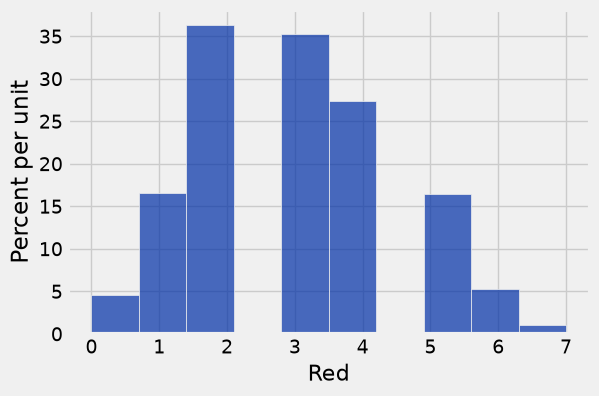

```python
bag = make_array(3/10, 7/10)
outcomes = make_array()

for _ in np.arange(1000):
    sample = sample_proportions(10, bag)
    red = sample.item(0) * 10
    outcomes = np.append(outcomes, red)

table = Table().with_column('Red', outcomes)
table.hist()
```

## Solution

```
3.0
```

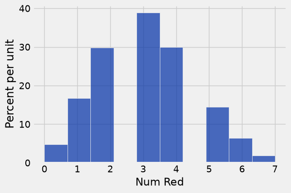

```python
bag_proportions = make_array(3/10, 7/10)
outcomes = make_array()

for _ in np.arange(1000):
    sample = sample_proportions(10, bag_proportions)
    num_red = sample.item(0) * 10
    outcomes = np.append(outcomes, num_red)

red_tbl = Table().with_column('Num Red', outcomes)
red_tbl.hist()
num_red
```

## Choosing the correct randomizer

Use np.random.choice, sample, or sample_proportions to generate the desired sample.

## Scenario 1

Select an element from the array arr with each element being equally likely.

```python
arr = make_array(1, 2, 3, 4)
np.random.choice(arr)
```

```
3
```

## Solution 1

```python
arr = make_array(1, 2, 3, 4)
np.random.choice(arr)
```

```
2
```

## Scenario 2

A bag contains 1 red ball, 3 green balls, and 6 yellow balls. Simulate the proportions resulting from drawing 5 balls from the bag (with replacement).

```python
bag = make_array(1/10, 3/10, 6/10)
sample = sample_proportions(5, bag)
sample
```

```
array([ 0.2,  0.4,  0.4])
```

## Solution 2

```python
bag_proportions = make_array(1/10, 3/10, 6/10)
sample = sample_proportions(5, bag_proportions)
sample
```

```
array([ 0.2,  0.6,  0.2])
```

## Scenario 3

Sample ten distinct movies from the table below.

```python
top_movies = Table.read_table('top_movies_2017.csv')
top_movies.sample(10, with_replacement=False)
```

| Title | Studio | Gross | Gross (Adjusted) | Year |
| --- | --- | --- | --- | --- |
| Saving Private Ryan | Dreamworks | 216540909 | 406691500 | 1998 |
| Beverly Hills Cop II | Paramount | 153665036 | 349381600 | 1987 |
| My Fair Lady | Warner Brothers | 72000000 | 533400000 | 1964 |
| Mission: Impossible II | Paramount | 215409889 | 355286400 | 2000 |
| The Greatest Showman on Earth | Paramount | 36000000 | 533400000 | 1952 |
| Iron Man 3 | Buena Vista | 409013994 | 433906300 | 2013 |
| Around the World in 80 Days | United Artists | 42000000 | 574430800 | 1956 |
| Harry Potter and the Sorcerer's Stone | Warner Brothers | 317575550 | 497066400 | 2001 |
| The Incredibles | Buena Vista | 261441092 | 373646300 | 2004 |
| Top Gun | Paramount | 179800601 | 426989100 | 1986 |

## Solution 3

```python
top_movies = Table.read_table('top_movies_2017.csv')
sample_tbl = top_movies.sample(10, with_replacement = False)
```